# Estudis d'Informàtica, Multimèdia i Telecomunicacions

# Mineria de dades: PRA2 - Modelat d’un joc de dades

Autor: Nom estudiant

Novembre 2019

Carrega de les llibreries que es necessiten

```r
library(arules)
library(C50)
library(caret)
library(class)
library(cluster)
library(dplyr)
library(factoextra)
library(fpc)
library(ggpubr)
library(ggplot2)
library(grid)
library(gridExtra)
library(mclust)
library(plyr)
library(randomForest)
library(rattle)
library(RColorBrewer)
library(rpart.plot)
library(rpart)
library(vcd)
```

```r
customer.data <- read.csv('retail-customer.csv', sep = ',')
customer.data.clean <- customer.data[,c('Days','NumInvoices','TotalCost','NumStocks')]
outliersLimits <- function(x) {
    limits <- c("above", "under")
    limits$above <- quantile(x, 0.75, type=6) + 1.5 * (quantile(x, 0.75, type=6) - quantile(x, 0.25, type=6))
    limits$under <- quantile(x, 0.25, type=6) - 1.5 * (quantile(x, 0.75, type=6) - quantile(x, 0.25, type=6))
  return(limits)
}

limits <- outliersLimits(customer.data.clean$TotalCost)
customer.data.clean <-subset(customer.data.clean, TotalCost >= limits$under)
customer.data.clean <-subset(customer.data.clean, TotalCost <= limits$above)
summary(customer.data.clean)
```

```
##       Days         NumInvoices       TotalCost         NumStocks
##  Min.   :  0.00   Min.   : 0.000   Min.   :-1592.5   Min.   :  0.00
##  1st Qu.: 20.90   1st Qu.: 1.000   1st Qu.:  264.6   1st Qu.: 14.00
##  Median : 57.00   Median : 2.000   Median :  567.4   Median : 31.00
##  Mean   : 99.01   Mean   : 2.889   Mean   :  855.1   Mean   : 48.14
##  3rd Qu.:157.10   3rd Qu.: 4.000   3rd Qu.: 1201.5   3rd Qu.: 64.00
##  Max.   :373.10   Max.   :39.000   Max.   : 3580.1   Max.   :580.00
```

```r
retail.product.data <- read.csv('retail-product.csv', sep = ',')
summary(retail.product.data)
```

```
##    UnitPrice       TotalStockUnits        Days        TotalStockPrice
##  Min.   :  0.000   Min.   :-1460.0   Min.   :  0.00   Min.   : -86541.1
##  1st Qu.:  1.010   1st Qu.:   67.0   1st Qu.:  0.90   1st Qu.:    142.7
##  Median :  1.950   Median :  414.5   Median :  3.10   Median :    750.7
##  Mean   :  3.818   Mean   : 1395.3   Mean   : 46.06   Mean   :   2861.7
##  3rd Qu.:  3.880   3rd Qu.: 1437.0   3rd Qu.: 32.02   3rd Qu.:   2373.4
##  Max.   :744.150   Max.   :53215.0   Max.   :373.10   Max.   :1064825.1
```

```r
product.data.clean <- retail.product.data[,c('UnitPrice', 'Days','TotalStockUnits')]

product.data.clean <- subset(product.data.clean, product.data.clean$TotalStockUnits > 0)
product.data.clean <- subset(product.data.clean, product.data.clean$UnitPrice > 0)
product.data.clean <- subset(product.data.clean, product.data.clean$Days > 0)
summary(product.data.clean)
```

```
##    UnitPrice            Days        TotalStockUnits
##  Min.   :  0.040   Min.   :  0.10   Min.   :    1
##  1st Qu.:  0.990   1st Qu.:  1.00   1st Qu.:   65
##  Median :  1.950   Median :  3.80   Median :  371
##  Mean   :  3.699   Mean   : 46.63   Mean   : 1227
##  3rd Qu.:  3.840   3rd Qu.: 34.90   3rd Qu.: 1264
##  Max.   :744.150   Max.   :373.10   Max.   :53215
```

```r
outliersLimits <- function(x) {
    limits <- c("above", "under")
    limits$above <- quantile(x, 0.75, type=6) + 1.5 * (quantile(x, 0.75, type=6) - quantile(x, 0.25, type=6))
    limits$under <- quantile(x, 0.25, type=6) - 1.5 * (quantile(x, 0.75, type=6) - quantile(x, 0.25, type=6))
  return(limits)
}

limits <- outliersLimits(product.data.clean$UnitPrice)
product.data.clean <-subset(product.data.clean, UnitPrice <= limits$above)

summary(product.data.clean)
```

```
##    UnitPrice          Days        TotalStockUnits
##  Min.   :0.040   Min.   :  0.10   Min.   :    1
##  1st Qu.:0.870   1st Qu.:  1.00   1st Qu.:   75
##  Median :1.660   Median :  3.80   Median :  426
##  Mean   :2.327   Mean   : 46.23   Mean   : 1306
##  3rd Qu.:3.150   3rd Qu.: 32.90   3rd Qu.: 1375
##  Max.   :8.110   Max.   :373.10   Max.   :53215
```

# 1 Mètode agregació jerarquica incremental (Hierarchical Agglomerative Clustering - HAC)

Funciona amb l’algoritme dels veïns més propers (k-nearest neighbours) de la següent forma:

- Assignem cada element al seu propi clúster, de manera que si té N elements, ara té N clústers, cadascun amb un sol element. Deixem que les distàncies (similitud) entre els clusters siguin iguals a les distàncies (similitud) entre els elements que contenen.
- Es troba el parell més proper (més similar) de clústers i es combinen en un únic clúster, de manera que ara tenim un clúster menys.
- Calculem distàncies (similitud) entre el nou clúster i cadascun dels clústers antics.
- Es repeteix els passos 2 i 3 fins que tots els elements siguin agrupats en un sol grup de mida N.

De formes de mesurar les distàncies entre grups tenim de diversos tipus. Provarem només: “average”, “complete” i “ward”.

## 1.1 Estudi de customers

Fem servir el dataframe: ‘customer.data.clean’ que hem generat a Clustering amb K-means o centroides:

Abans de tot, normalitzem les dades i calculem la distància euclidiana entre els elements.

```r
## creem la funció per normalitzar
ni <-function (x) {(x -min (x)) / (max (x) -min (x))}
customer.data.norm <- as.data.frame(lapply(customer.data.clean[,1:4], ni))
# primer fem la matriu de la distància euclideana dels elements de la taula de llavors.
customer.data.euc <- dist(customer.data.norm, method = "euclidean")
```

### 1.1.1 Enllaç complet

Estratègia de la distància màxima o similitud mínima. En aquest mètode, també conegut (complete linkage), es considera que la distància o similitud entre dos clústers cal mesurar-la atenent a elements més dispars, és a dir, la distància o similitud entre clústers ve dada, respectivament, per la màxima distància (o mínima similitud) entre components dels clústers.

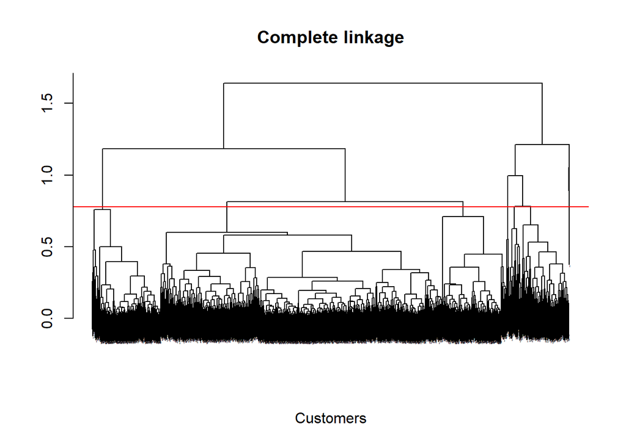

```r
# fem servir hclust per a realitzar les agrupacions
hc1 <- hclust(customer.data.euc, method = "complete")
plot(hc1,
     main = "Complete linkage",
     xlab = "Customers",
     ylab = "",
     cex = 0.04,
     sub = "")
abline(h = 0.78, col = "red")
```

El dendograma ens està mostrant les distàncies euclidianes entre els diferents elements (customers) de la mostra i la separació gràfica conformes en van agrupant els clusters. Les interpretació és subjectiva però agafariem 4 i 6 clusters.

### 1.1.2 Enllaç promig

En aquesta estratègia la distància, o similitud, de l’clúster Ci amb el Cj s’obté com la mitjana aritmètica entre la distància, o similitud, dels elements d’aquests clústers.

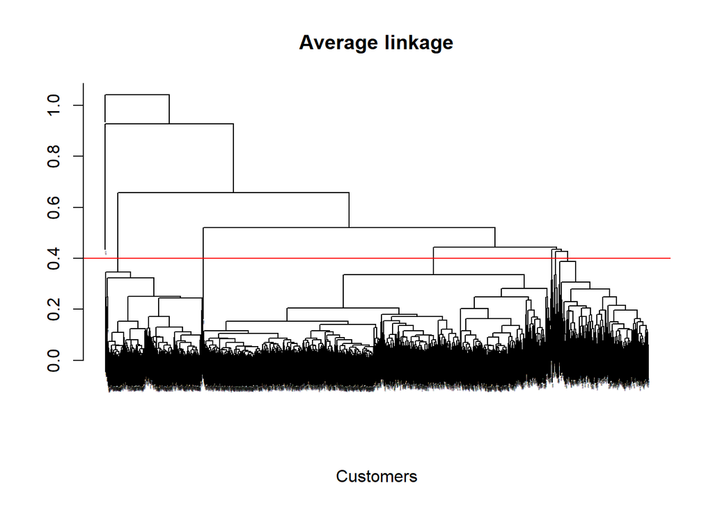

```r
hc2 <- hclust(customer.data.euc, method = "average")

plot(hc2,
     main = "Average linkage",
     xlab = "Customers",
     ylab = "",
     cex = 0.1,
     sub = "")
abline(h = 0.4, col = "red")
```

Similar, entre 4 i 7 grups de customers.

### 1.1.3 Mètode Ward

El mètode de Ward apunta a minimitzar la variància total dins de el grup. A cada pas, es fusionen el parell de clústers amb una distància mínima entre els clústers. En altres paraules, forma grups d’una manera que minimitza la pèrdua associada amb cada grup. Té molt bona efectivitat a l’hora d’agrupar.

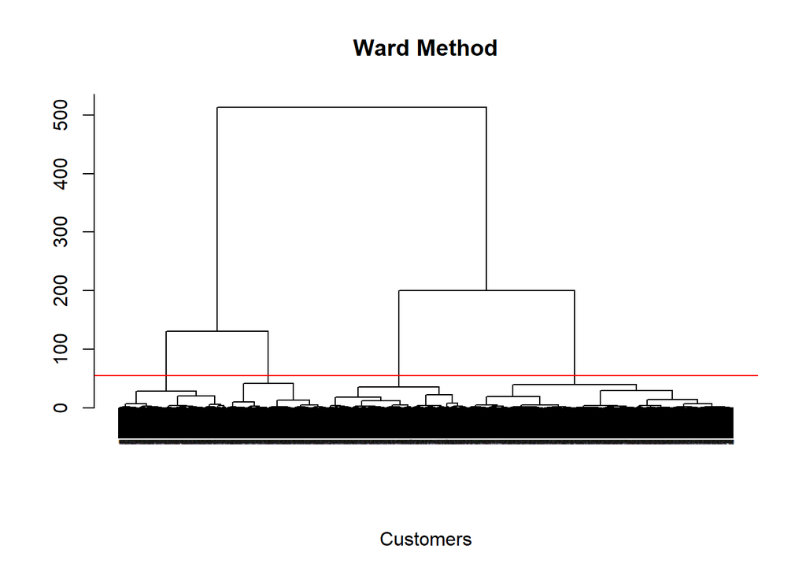

```r
hc3 <- hclust(customer.data.euc, method = "ward.D")

plot(hc3,
     main = "Ward Method",
     xlab = "Customers",
     ylab = "",
     cex = 0.1,
     sub = "")
abline(h = 55, col = "red")
```

Amb el mètode ward veiem més clarament 4 grups de clients. Els altres clusters es troben molt més allunyats en l’agrupació. Ens quedariem amb 4 grups de customers.

Dels 3 mètodes que hem fet servir el que dona una més bona interpretació és ward on podem veure 4 clusters.

## 1.2 Estudi de productes

Fem servir el dataframe: ‘product.data.clean’ que hem generat a Clustering amb K-means o centroides:

Abans de tot, normalitzem les dades i calculem la distància euclidiana entre els elements.

```r
## creem la funció per normalitzar
ni <-function (x) {(x -min (x)) / (max (x) -min (x))}
product.data.norm <- as.data.frame(lapply(product.data.clean[,1:3], ni))
# primer fem la matriu de la distància euclideana dels elements de la taula de llavors.
product.data.euc <- dist(product.data.norm, method = "euclidean")
```

Executem les mateixes estratègies que hem fet servir amb Customers

### 1.2.1 Enllaç complet

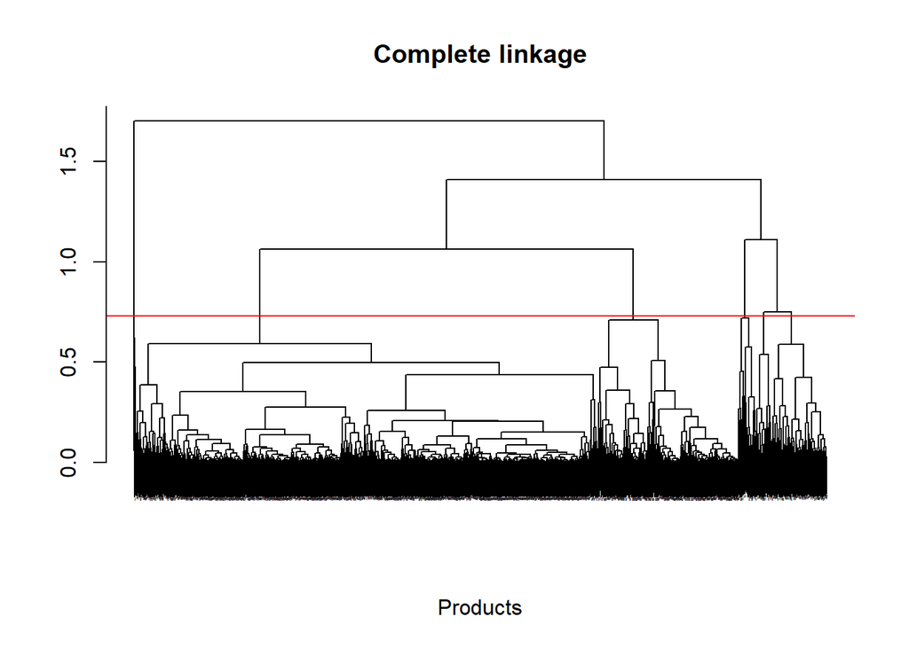

```r
# fem servir hclust per a realitzar les agrupacions
hc1 <- hclust(product.data.euc, method = "complete")
plot(hc1,
     main = "Complete linkage",
     xlab = "Products",
     ylab = "",
     cex = 0.01,
     sub = "")
abline(h = 0.73, col = "red")
```

El dendograma ens està mostrant les distàncies euclidianes entre els diferents elements (productes) de la mostra. Mostra la separació dels elements i dels clusters que es van formant. Sembla distingir entre 3 i 5 clusters

### 1.2.2 Mètode Ward

Exectarem directament amb el mètode ward on veiem que tenim 4 clusters diferenciats.

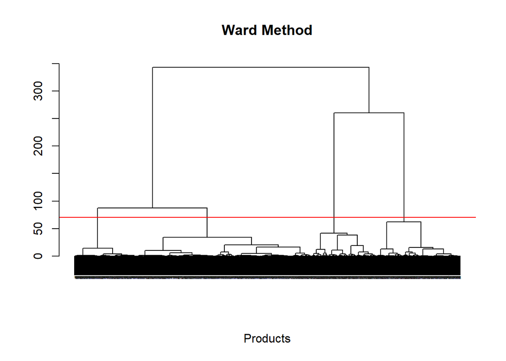

```r
hc3 <- hclust(product.data.euc, method = "ward.D")

plot(hc3,
     main = "Ward Method",
     xlab = "Products",
     ylab = "",
     cex = 0.1,
     sub = "")
abline(h = 70, col = "red")
```

# 2 Mètodes d’agregació probabilítics

Els enfocaments dels mètodes probabilístics assumeixen una varietat de models de dades i apliquen l’estimació de màxima versemblança i els criteris de Bayes per identificar el model més probable i el nombre de grups.

Anem a realitzar clusters a partir d’algoritmes probabilístics amb atributs 2 a 2

## 2.1 Estudi de customers

```r
mclust <- Mclust(customer.data.norm[,1:4])
summary(mclust)
```

```
## ----------------------------------------------------
## Gaussian finite mixture model fitted by EM algorithm
## ----------------------------------------------------
##
## Mclust VVE (ellipsoidal, equal orientation) model with 9 components:
##
##  log-likelihood    n df      BIC      ICL
##        20493.38 3949 86 40274.57 38311.25
##
## Clustering table:
##   1   2   3   4   5   6   7   8   9
## 299 597 305 669 353 569 527 206 424
```

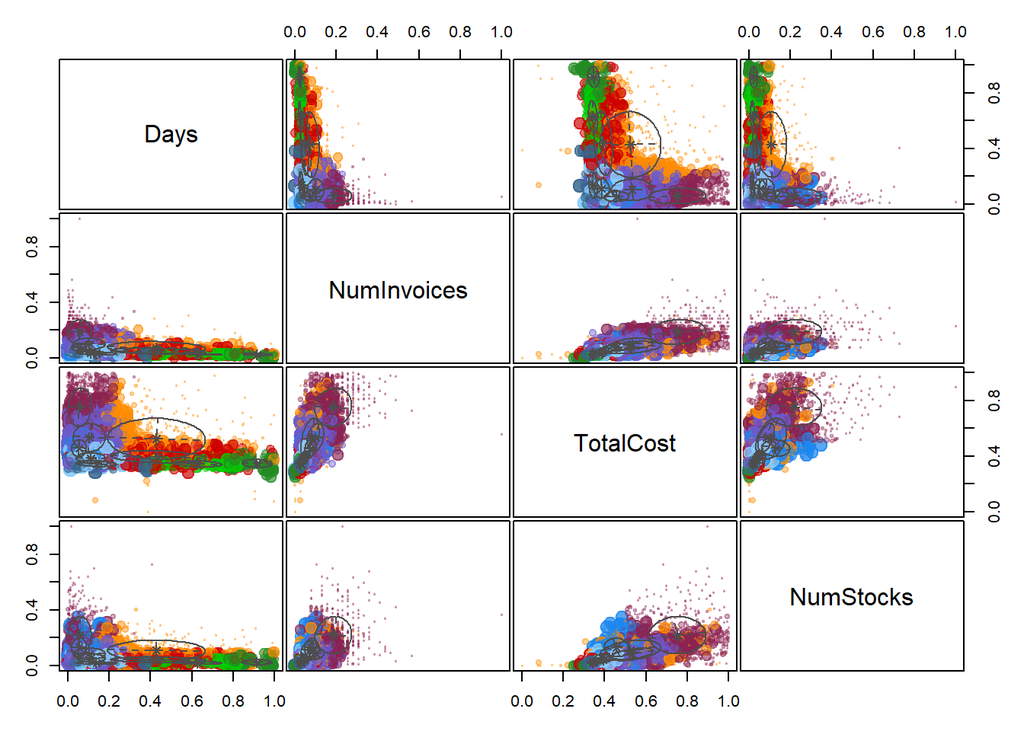

```r
plot(mclust, what = "uncertainty")
```

Visualment sembla que es generan al voltant d’uns 5 grups diferenciats. Ens està dient que en surten 9.

Anem a fer un estudi amb 2 atributs.

### 2.1.1 Days x TotalCost

```r
mclust <- Mclust(customer.data.norm[,c("Days","TotalCost")])
summary(mclust)
```

```
## ----------------------------------------------------
## Gaussian finite mixture model fitted by EM algorithm
## ----------------------------------------------------
##
## Mclust VVI (diagonal, varying volume and shape) model with 9 components:
##
##  log-likelihood    n df      BIC      ICL
##        5041.314 3949 44 9718.254 7150.587
##
## Clustering table:
##   1   2   3   4   5   6   7   8   9
## 194 536 460 619 117 506 691 433 393
```

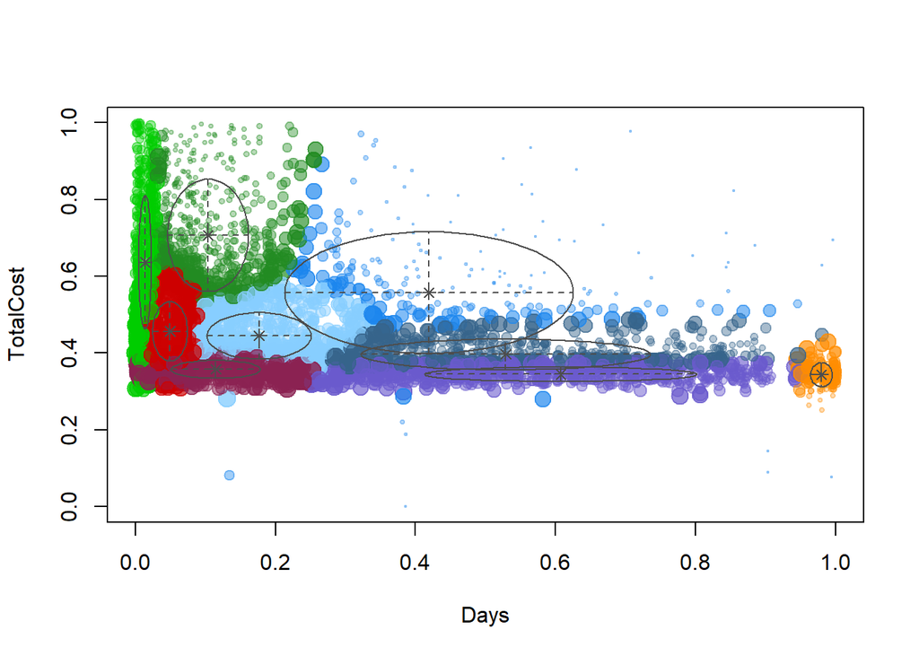

```r
plot(mclust, what = "uncertainty")
```

Amb la l’estudi de Days i total cost ens està mostant fins a 9 grups diferents.

### 2.1.2 NumStocks x TotalCost

```r
mclust <- Mclust(customer.data.norm[,c("NumStocks","TotalCost")])
summary(mclust)
```

```
## ----------------------------------------------------
## Gaussian finite mixture model fitted by EM algorithm
## ----------------------------------------------------
##
## Mclust VVV (ellipsoidal, varying volume, shape, and orientation) model with 9
## components:
##
##  log-likelihood    n df      BIC      ICL
##        10795.41 3949 53 21151.92 19069.76
##
## Clustering table:
##   1   2   3   4   5   6   7   8   9
## 968 134 148 519 263 256 347 535 779
```

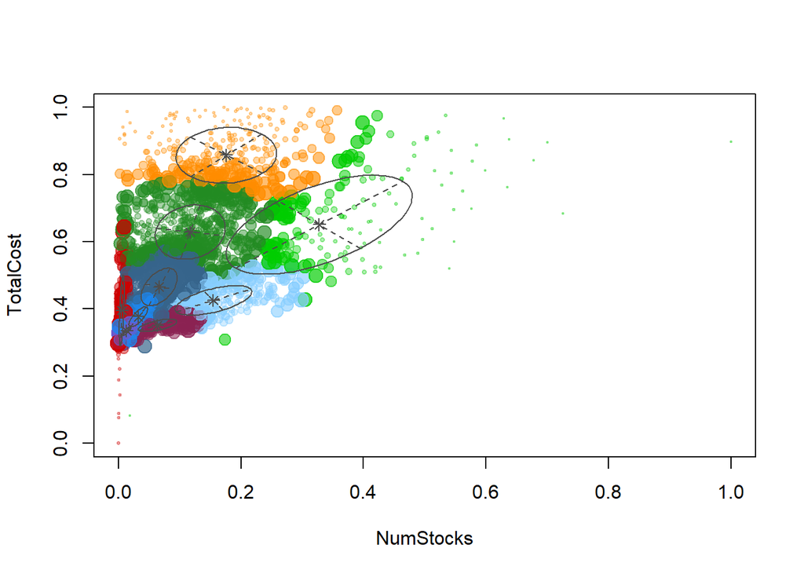

```r
plot(mclust, what = "uncertainty")
```

## Estudi de productes

```r
mclust <- Mclust(product.data.norm[,1:3])
summary(mclust)
```

```
## ----------------------------------------------------
## Gaussian finite mixture model fitted by EM algorithm
## ----------------------------------------------------
##
## Mclust VVE (ellipsoidal, equal orientation) model with 9 components:
##
##  log-likelihood    n df      BIC      ICL
##         17939.4 3380 65 35350.63 33790.31
##
## Clustering table:
##   1   2   3   4   5   6   7   8   9
## 403 467 110 232 105 818 318 643 284
```

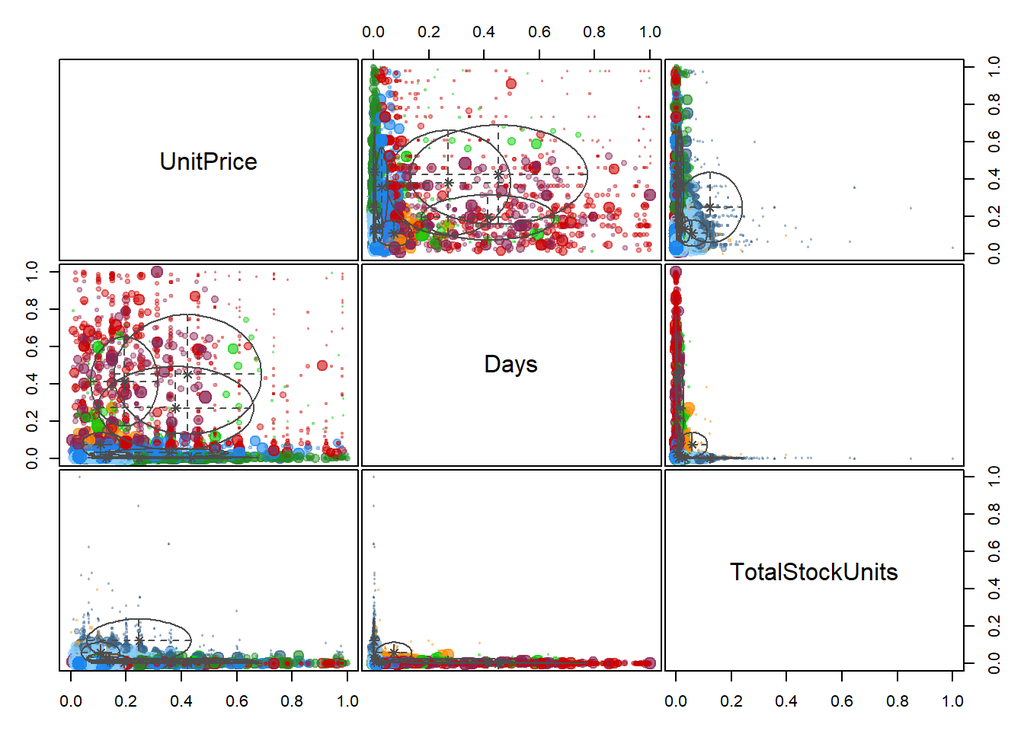

```r
plot(mclust, what = "uncertainty")
```

### 2.1.3 UnitPrice x Days

```r
mclust <- Mclust(product.data.norm[,c("Days","UnitPrice")])
summary(mclust)
```

```
## ----------------------------------------------------
## Gaussian finite mixture model fitted by EM algorithm
## ----------------------------------------------------
##
## Mclust VVE (ellipsoidal, equal orientation) model with 9 components:
##
##  log-likelihood    n df      BIC      ICL
##        7809.611 3380 45 15253.57 14105.79
##
## Clustering table:
##   1   2   3   4   5   6   7   8   9
## 271 947 349 235 397 396 283 448  54
```

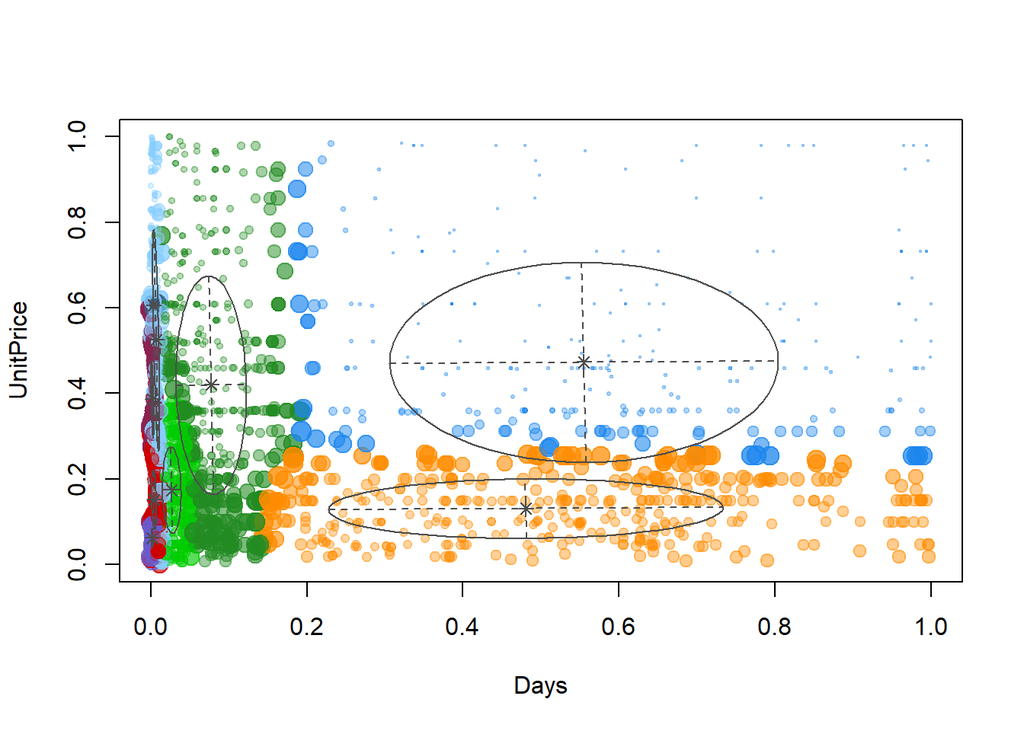

```r
plot(mclust, what = "uncertainty")
```

### 2.1.4 UnitPrice x TotalStockUnits

```r
mclust <- Mclust(product.data.norm[,c("UnitPrice","TotalStockUnits")])
summary(mclust)
```

```
## ----------------------------------------------------
## Gaussian finite mixture model fitted by EM algorithm
## ----------------------------------------------------
##
## Mclust VVI (diagonal, varying volume and shape) model with 7 components:
##
##  log-likelihood    n df      BIC      ICL
##        10955.38 3380 34 21634.48 20128.53
##
## Clustering table:
##   1   2   3   4   5   6   7
## 535  37 700 436 540 195 937
```

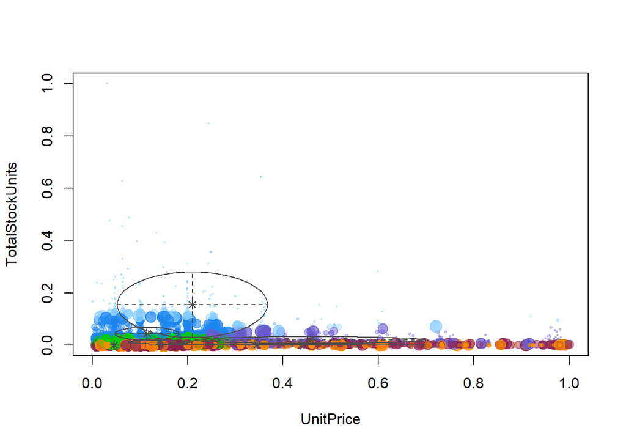

```r
plot(mclust, what = "uncertainty")
```

### 2.1.5 TotalStockUnits x Days

```r
mclust <- Mclust(product.data.norm[,c("TotalStockUnits","Days")])
summary(mclust)
```

```
## ----------------------------------------------------
## Gaussian finite mixture model fitted by EM algorithm
## ----------------------------------------------------
##
## Mclust VVV (ellipsoidal, varying volume, shape, and orientation) model with 9
## components:
##
##  log-likelihood    n df      BIC      ICL
##        17554.67 3380 53 34678.68 33178.67
##
## Clustering table:
##   1   2   3   4   5   6   7   8   9
## 669 624 285 400 399 362  70 299 272
```

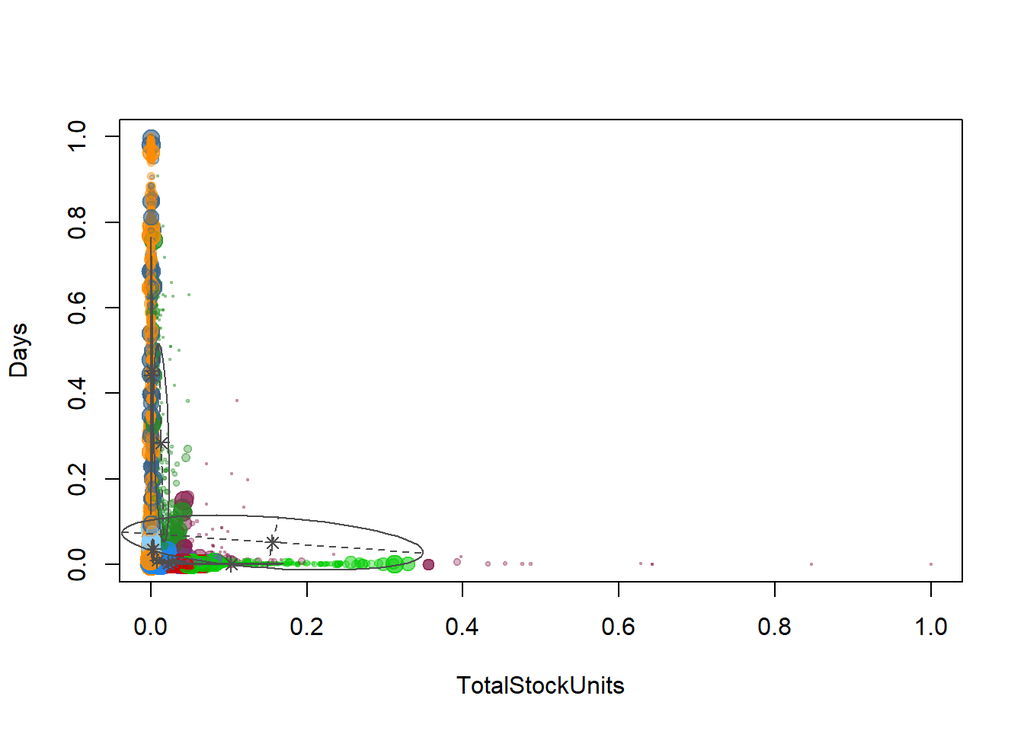

```r
plot(mclust, what = "uncertainty")
```